Capstone Project: Product Recommendation System

**AUTHOR: Harish Ram**  
**DATASET:** [Personalized Recommendation Dataset](https://www.kaggle.com/datasets/alfarisbachmid/personalized-recommendation-systems-dataset)

# Capstone — Part 1 of 3: Exploratory Data Analysis

This notebook is **Part 1 of a 3-part capstone project** (split for reliable rendering on GitHub):

1. **Part 1 — Exploratory Data Analysis**
2. **Part 2 — Modeling: Baselines, Collaborative Filtering & Segmentation**
3. **Part 3 — Supervised Regression & Conclusions**

The parts are designed to be run **in order, in the same Jupyter session**, mirroring a standard multi-notebook capstone layout. All cell outputs from the original run are preserved below.

This notebook loads the data and explores its size, quality, distributions, sparsity, and the rating target before any modeling. It is fully self-contained.

1) IMPORT LIBRARIES

```python
import os
import pandas as pd
import numpy as np
import matplotlib.pyplot as plt
import seaborn as sns
import plotly.express as px
import time
import warnings

# Folder for exported figures (used in README.md)
IMAGES_DIR = 'images'
os.makedirs(IMAGES_DIR, exist_ok=True)

# Machine Learning Libraries for Baseline Model
from sklearn.preprocessing import StandardScaler
from sklearn.model_selection import train_test_split, cross_val_score, KFold, GroupKFold
from sklearn.pipeline import Pipeline
from sklearn.compose import ColumnTransformer
from sklearn.linear_model import LinearRegression, Ridge
from sklearn.metrics import mean_squared_error, mean_absolute_error, silhouette_score
from sklearn.dummy import DummyRegressor
from sklearn.ensemble import RandomForestRegressor, GradientBoostingRegressor
from sklearn.cluster import KMeans
from sklearn.decomposition import PCA
from surprise import Dataset, Reader, SVD, accuracy as surp_acc
from surprise.model_selection import cross_validate
from surprise.model_selection import train_test_split as surprise_split

warnings.filterwarnings('ignore', category=FutureWarning)
warnings.filterwarnings('ignore', category=RuntimeWarning) #suppress benign numpy/sklearn matmul + plotting warnings
warnings.filterwarnings('ignore', category=UserWarning)

# Set visualization style
sns.set_theme(style="whitegrid")
```

```python
# Check scikit-surprise is available (install manually if missing: pip install scikit-surprise)
try:
    from surprise import Dataset, Reader, SVD
    from surprise import accuracy as surprise_accuracy
    from surprise.model_selection import cross_validate, train_test_split as surprise_split
    print("scikit-surprise ready")
except ImportError:
    raise ImportError("scikit-surprise not found. Run: pip install scikit-surprise==1.1.4 numpy==1.26.4")
```

```
scikit-surprise ready
```

2) IMPORT DATA

```python
# Load the dataset
df = pd.read_csv('personalized_recommendation_dataset.csv')
```

3) DATA EXPLORATION

📋 WHAT WE ARE DOING HERE

We explore the data to understand its size, shape, duplicity, gaps, quality, distributions, sparsity, re-ratings, and the target (Rating) before any modeling. Inspect summary stats, and cardinality. These answers drive encoding choices and whether collaborative filtering is feasible.

3a) Basic Exploration - Info, Describe, Shape etc

```python
df.head()
```

|  | User_ID | Item_ID | Category | Rating | Timestamp | Price | Platform | Location |
| --- | --- | --- | --- | --- | --- | --- | --- | --- |
| 0 | User_913 | Item_52 | Movies | 2.0 | 2023-05-15 | 369.55 | Web | Africa |
| 1 | User_3457 | Item_66 | Electronics | 1.4 | 2023-08-19 | 255.15 | Web | Africa |
| 2 | User_1629 | Item_1467 | Sports | 2.7 | 2024-03-27 | 296.69 | Web | Europe |
| 3 | User_3463 | Item_697 | Movies | 1.6 | 2023-12-03 | 55.59 | Tablet | North America |
| 4 | User_2941 | Item_1736 | Games | 3.4 | 2023-02-06 | 366.22 | Web | South America |

```python
df.info()
# Mostly String Columns and 2 Float columns
# Timestamp is stored as String - need to convert it to DateTime
```

```
<class 'pandas.DataFrame'>
RangeIndex: 150000 entries, 0 to 149999
Data columns (total 8 columns):
 #   Column     Non-Null Count   Dtype
---  ------     --------------   -----
 0   User_ID    150000 non-null  str
 1   Item_ID    150000 non-null  str
 2   Category   150000 non-null  str
 3   Rating     150000 non-null  float64
 4   Timestamp  150000 non-null  str
 5   Price      150000 non-null  float64
 6   Platform   150000 non-null  str
 7   Location   150000 non-null  str
dtypes: float64(2), str(6)
memory usage: 9.2 MB
```

```python
df.shape
# Data has 150K rows and 8 Columns
```

```
(150000, 8)
```

```python
df.describe()
# Ratings from 1 to 5 - Uniform Distribution
# price from $5 to $500 - No outliers
```

|  | Rating | Price |
| --- | --- | --- |
| count | 150000.000000 | 150000.000000 |
| mean | 2.994918 | 252.312944 |
| std | 1.153429 | 142.754120 |
| min | 1.000000 | 5.000000 |
| 25% | 2.000000 | 128.817500 |
| 50% | 3.000000 | 252.610000 |
| 75% | 4.000000 | 375.630000 |
| max | 5.000000 | 500.000000 |

```python
# Unique Values of Str
print('--- Cardinality ---')
for col in ['User_ID', 'Item_ID', 'Category', 'Platform', 'Location']:
    print(f"{col}: {df[col].nunique():,} unique")
# The Categorical columns have manageable unique values - so we can do "One Hot Encoding"
```

```
--- Cardinality ---
User_ID: 5,000 unique
Item_ID: 2,000 unique
Category: 9 unique
Platform: 4 unique
Location: 6 unique
```

📋 WHAT WE ARE DOING HERE

**3b — Data quality.** Confirm no missing core fields and no duplicate rows. If both pass, we can focus on modeling rather than cleaning.

3b) Check for Nulls, Duplicates

```python
df.isnull().sum()
# There are no missing / null data in the dataframe.
```

```
User_ID      0
Item_ID      0
Category     0
Rating       0
Timestamp    0
Price        0
Platform     0
Location     0
dtype: int64
```

```python
print(f"Duplicate rows found: {df.duplicated().sum()}")
# No Duplicates found
```

```
Duplicate rows found: 0
```

3c) Converting "Timestamp" to DateTime

📋 WHAT WE ARE DOING HERE

**3c — Timestamps.** Parse dates and add Year/Month. Temporal fields support EDA plots and the **leave-last-out** split in Cell 6.

```python
df['Timestamp'] = pd.to_datetime(df['Timestamp'])
df.info()
```

```
<class 'pandas.DataFrame'>
RangeIndex: 150000 entries, 0 to 149999
Data columns (total 8 columns):
 #   Column     Non-Null Count   Dtype
---  ------     --------------   -----
 0   User_ID    150000 non-null  str
 1   Item_ID    150000 non-null  str
 2   Category   150000 non-null  str
 3   Rating     150000 non-null  float64
 4   Timestamp  150000 non-null  datetime64[us]
 5   Price      150000 non-null  float64
 6   Platform   150000 non-null  str
 7   Location   150000 non-null  str
dtypes: datetime64[us](1), float64(2), str(5)
memory usage: 9.2 MB
```

```python
# Extract Year and Month for temporal analysis
df['Year'] = df['Timestamp'].dt.year
df['Month'] = df['Timestamp'].dt.month
# df['dow'] = df['Timestamp'].dt.dayofweek + 1 -- Finding Day of the week (1-7)
df.info()
```

```
<class 'pandas.DataFrame'>
RangeIndex: 150000 entries, 0 to 149999
Data columns (total 10 columns):
 #   Column     Non-Null Count   Dtype
---  ------     --------------   -----
 0   User_ID    150000 non-null  str
 1   Item_ID    150000 non-null  str
 2   Category   150000 non-null  str
 3   Rating     150000 non-null  float64
 4   Timestamp  150000 non-null  datetime64[us]
 5   Price      150000 non-null  float64
 6   Platform   150000 non-null  str
 7   Location   150000 non-null  str
 8   Year       150000 non-null  int32
 9   Month      150000 non-null  int32
dtypes: datetime64[us](1), float64(2), int32(2), str(5)
memory usage: 10.3 MB
```

```python
df.head()
```

|  | User_ID | Item_ID | Category | Rating | Timestamp | Price | Platform | Location | Year | Month |
| --- | --- | --- | --- | --- | --- | --- | --- | --- | --- | --- |
| 0 | User_913 | Item_52 | Movies | 2.0 | 2023-05-15 | 369.55 | Web | Africa | 2023 | 5 |
| 1 | User_3457 | Item_66 | Electronics | 1.4 | 2023-08-19 | 255.15 | Web | Africa | 2023 | 8 |
| 2 | User_1629 | Item_1467 | Sports | 2.7 | 2024-03-27 | 296.69 | Web | Europe | 2024 | 3 |
| 3 | User_3463 | Item_697 | Movies | 1.6 | 2023-12-03 | 55.59 | Tablet | North America | 2023 | 12 |
| 4 | User_2941 | Item_1736 | Games | 3.4 | 2023-02-06 | 366.22 | Web | South America | 2023 | 2 |

➡️ WHAT TO DO NEXT (and why)

Timestamps and Year/Month are ready. Continue numeric/categorical/temporal EDA (**3d–3f**)

3d) Numerical Feature Analysis

📋 WHAT WE ARE DOING HERE

**3d — Numeric EDA.** Visualize Price and Rating; compute correlations. These will help us determine feature engineering while modeling

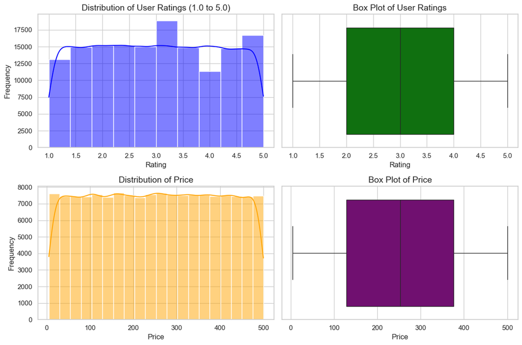

```python
# Change (1, 2) to (2, 2) to create 4 plots
fig, axes = plt.subplots(2, 2, figsize=(12,8))

# Plot 1: Distribution of Ratings (Top Left)
sns.histplot(df['Rating'], bins=10, kde=True, ax=axes[0, 0], color='blue')
axes[0, 0].set_title('Distribution of User Ratings (1.0 to 5.0)', fontsize=14)
axes[0, 0].set_xlabel('Rating', fontsize=12)
axes[0, 0].set_ylabel('Frequency', fontsize=12)

# Plot 2: Boxplot of Ratings (Top Right)
sns.boxplot(x=df['Rating'], ax=axes[0, 1], color='green')
axes[0, 1].set_title('Box Plot of User Ratings', fontsize=14)
axes[0, 1].set_xlabel('Rating', fontsize=12)

# Plot 3: Distribution of Price (Bottom Left)
sns.histplot(df['Price'], bins=20, kde=True, ax=axes[1, 0], color='orange')
axes[1, 0].set_title('Distribution of Price', fontsize=14)
axes[1, 0].set_xlabel('Price', fontsize=12)
axes[1, 0].set_ylabel('Frequency', fontsize=12)

# Plot 4: Boxplot of Price (Bottom Right)
sns.boxplot(x=df['Price'], ax=axes[1, 1], color='purple')
axes[1, 1].set_title('Box Plot of Price', fontsize=14)
axes[1, 1].set_xlabel('Price', fontsize=12)

plt.tight_layout()
plt.savefig(os.path.join(IMAGES_DIR, 'eda_distributions.png'), dpi=150, bbox_inches='tight')
plt.show()
```

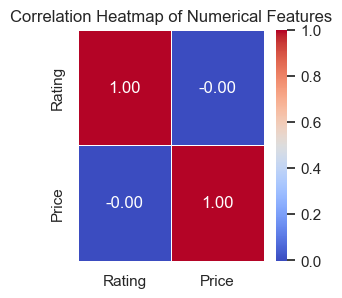

```
Spearman correlation Rating vs Price (full data): -0.0015
```

```python
# Calculate the correlation matrix
corr_matrix = df.select_dtypes(include=['float64']).corr()

# Plot the heatmap
plt.figure(figsize=(3,3))
sns.heatmap(corr_matrix, annot=True, cmap='coolwarm', fmt=".2f", linewidths=0.5)
plt.title('Correlation Heatmap of Numerical Features')
plt.show()

# Checking Spearman Correlation
print(f"Spearman correlation Rating vs Price (full data): {df['Rating'].corr(df['Price'], method='spearman'):.4f}")
```

➡️ WHAT TO DO NEXT

Both Ratings and Price have a very **UNIFORM** distribution - Could be the side effect of synthetic data

There is **no or negligible correlation** between Price and Rating - which is common in e-commerce data.

3e) Categorical Feature Analysis

📋 WHAT WE ARE DOING HERE

**3e — Categorical EDA.** Visualize distribution of data and target variable (Rating) against different Categorical data to reveal any skewness, outliers etcThese will help us determine feature engineering while modeling

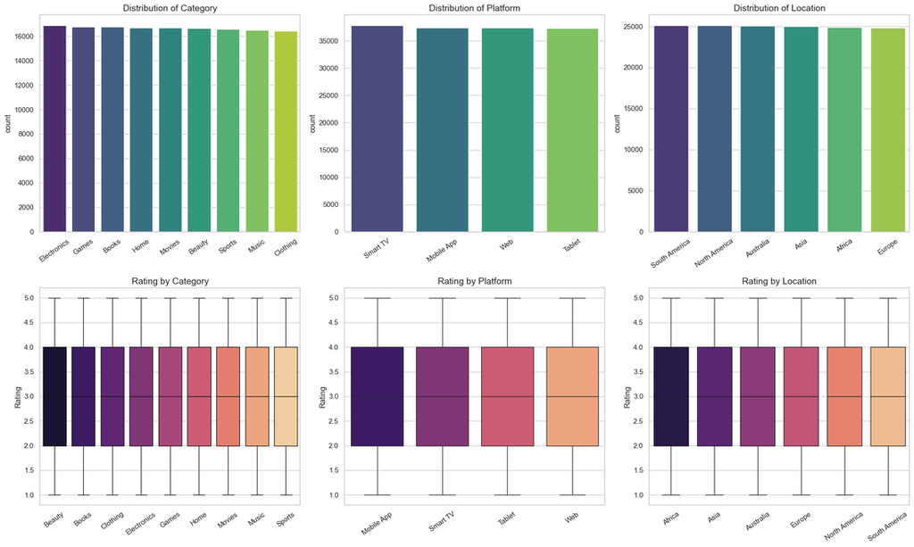

```python
# Identify categorical columns to plot
cat_cols = ['Category', 'Platform', 'Location']

fig, axes = plt.subplots(2, 3, figsize=(20, 12))

for i, col in enumerate(cat_cols):
    # --- Row 0: Countplots ---
    sns.countplot(data=df, x=col, ax=axes[0, i], palette='viridis',
                  order=df[col].value_counts().index)
    axes[0, i].set_title(f'Distribution of {col}', fontsize=14)
    axes[0, i].tick_params(axis='x', rotation=35)
    axes[0, i].set_xlabel('')

    # --- Row 1: Rating Boxplots ---
    order = df.groupby(col)['Rating'].median().sort_values().index
    sns.boxplot(data=df, x=col, y='Rating', ax=axes[1, i], palette='magma',
                order=order)
    axes[1, i].set_title(f'Rating by {col}', fontsize=14)
    axes[1, i].tick_params(axis='x', rotation=35)
    axes[1, i].set_xlabel('')

plt.tight_layout()
plt.show()
```

➡️ WHAT TO DO NEXT

We have equal representation of each categorical column in the data set (9 Categories, 4 Platforms and 6 Locations) - Could be the side effect of synthetic data. This might create some challenges with the Modeling down below

3f) Temporal Feature Analysis

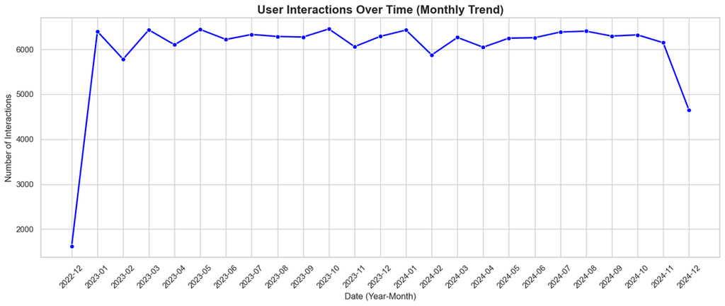

```python
interactions_over_time = df.groupby(['Year', 'Month']).size().reset_index(name='Interaction_Count')

# Combine them into a single string column purely for plotting a continuous x-axis (e.g., "2023-05")
interactions_over_time['Time_Period'] = interactions_over_time['Year'].astype(str) + '-' + interactions_over_time['Month'].astype(str).str.zfill(2)

# Create the Line Plot
plt.figure(figsize=(14, 6))
sns.lineplot(data=interactions_over_time, x='Time_Period', y='Interaction_Count',
             marker='o', color='blue', linewidth=2)

plt.title('User Interactions Over Time (Monthly Trend)', fontsize=16, fontweight='bold')
plt.xlabel('Date (Year-Month)', fontsize=12)
plt.ylabel('Number of Interactions', fontsize=12)
plt.xticks(rotation=45) # Rotate x-axis labels so they don't overlap

plt.tight_layout()
plt.show()

# There is always a dip in February and April
# May thru October seems stable between 2023 and 2024
```

3g) User vs Item - Density, Sparsity and Distribution of Ratings

📋 WHAT WE ARE DOING HERE

**3g — Sparsity & activity.** Measure how full the user×item matrix is and whether activity is long-tailed. How many Users and Items we have -- how many Ratings is possible vs how many we have. This justifies matrix factorization (SVD) and cold-start fallbacks.

```python
# User–item matrix sparsity
print(f"Unique users: {df['User_ID'].nunique():,}")
print(f"Unique items: {df['Item_ID'].nunique():,}")
print(f"Observed interactions (# of rows): {len(df):,}")
print(f"Full matrix size (users × items): {df['User_ID'].nunique()*df['Item_ID'].nunique():,}")
print(f"Density (interactions / matrix cells): {len(df) / (df['User_ID'].nunique()*df['Item_ID'].nunique()):.3%}")
```

```
Unique users: 5,000
Unique items: 2,000
Observed interactions (# of rows): 150,000
Full matrix size (users × items): 10,000,000
Density (interactions / matrix cells): 1.500%
```

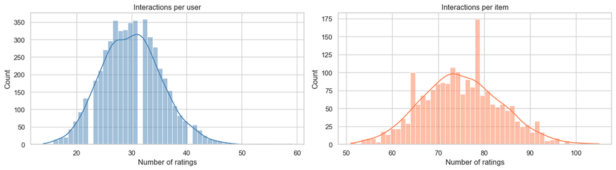

```
------------------------------------------
Average # of ratings/user: 30.00
Min # of ratings/user: 14.00
Max # of ratings/user: 59.00
------------------------------------------
Average ratings/item: 75.00
Min # of ratings/item: 51.00
Max # of ratings/item: 105.00
```

```python
# 1) User and item activity — long-tail distributions
fig, axes = plt.subplots(1, 2, figsize=(14, 4))
sns.histplot(df.groupby('User_ID').size(), bins=50, kde=True, ax=axes[0], color='steelblue')
axes[0].set_title('Interactions per user')
axes[0].set_xlabel('Number of ratings')
sns.histplot(df.groupby('Item_ID').size(), bins=50, kde=True, ax=axes[1], color='coral')
axes[1].set_title('Interactions per item')
axes[1].set_xlabel('Number of ratings')
plt.tight_layout()
plt.savefig(os.path.join(IMAGES_DIR, 'sparsity_activity.png'), dpi=150, bbox_inches='tight')
plt.show()
print('------------------------------------------')
print(f"Average # of ratings/user: {df.groupby('User_ID').size().mean():.2f}")
print(f"Min # of ratings/user: {df.groupby('User_ID').size().min():.2f}")
print(f"Max # of ratings/user: {df.groupby('User_ID').size().max():.2f}")
print('------------------------------------------')
print(f"Average ratings/item: {df.groupby('Item_ID').size().mean():.2f}")
print(f"Min # of ratings/item: {df.groupby('Item_ID').size().min():.2f}")
print(f"Max # of ratings/item: {df.groupby('Item_ID').size().max():.2f}")
```

➡️ WHAT TO DO NEXT (and why)

3h) Duplication - Has the same Customer rated the same item multiple times over the years / months

📋 WHAT WE ARE DOING HERE

**3h — Re-ratings.** Count duplicate (user, item) pairs - Is the same Customer rating the same item again and again over time? Duplicates matter because during Modeling we will aggregate them to one rating per pair before Surprise training.

```python
pair_dupes = df.duplicated(subset=['User_ID', 'Item_ID'], keep=False)
n_dup_rows = pair_dupes.sum()
n_multi_pairs = (df.groupby(['User_ID', 'Item_ID']).size() > 1).sum()
print(f"# of Records with same User/Item pair: {n_dup_rows:,}")
print(f"Distinct (user, item) pairs with >1 record: {n_multi_pairs:,}")
```

```
# of Records with same User/Item pair: 2,213
Distinct (user, item) pairs with >1 record: 1,105
```

➡️ WHAT TO DO NEXT (and why)

As duplicate (user, item) pairs exist, we will probably average them before training Surprise. Finish with heatmaps/recency if desired, then **3k** rating counts. *Why:* uniform star ratings inflate RMSE and favor ranking metrics.

3i) HeatMaps - Average Ratings by Categorical Features

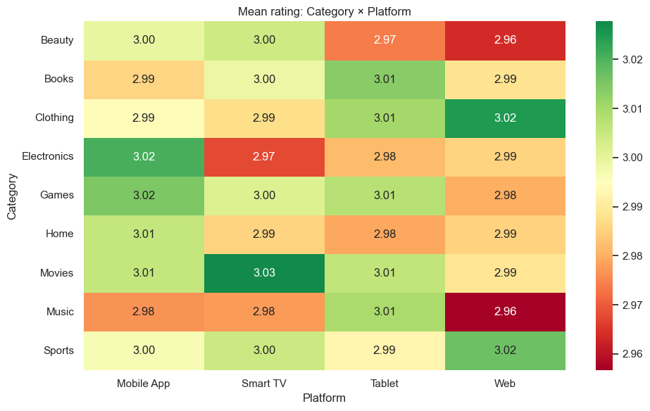

```python
# Mean rating heatmap — Category × Platform
pivot = df.pivot_table(values='Rating', index='Category', columns='Platform', aggfunc='mean')
plt.figure(figsize=(10, 6))
sns.heatmap(pivot, annot=True, fmt='.2f', cmap='RdYlGn', center=df['Rating'].mean())
plt.title('Mean rating: Category × Platform')
plt.tight_layout()
plt.show()
```

➡️ WHAT TO DO NEXT (and why)

The ratings are incredibly tight, ranging only from 2.96 to 3.03. This could mean: - Stability - User Experience and Sentiment is consistent OR - No "Too Bad" or "Wow" factors - No category or plaform is breaking too low or too high.

3j) Recency of the data relative to the latest date in the data

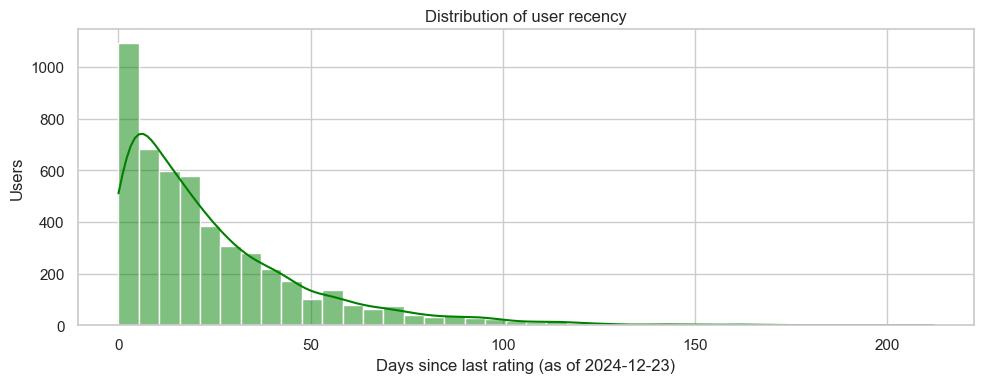

```
Median days since last interaction: 17
```

```python
# User recency — days since last interaction (relative to max timestamp in data)
ref = df['Timestamp'].max()
last_per_user = df.groupby('User_ID')['Timestamp'].max()
days_since = (ref - last_per_user).dt.days
plt.figure(figsize=(10, 4))
sns.histplot(days_since, bins=40, kde=True, color='green')
plt.xlabel(f'Days since last rating (as of {ref.date()})')
plt.ylabel('Users')
plt.title('Distribution of user recency')
plt.tight_layout()
plt.show()
print(f"Median days since last interaction: {days_since.median():.0f}")

# Data is relatively new and recent compared to the latest record in the dataframe - which is good.
```

📋 WHAT WE ARE DOING HERE

**3k — Target distribution.** How often does each star rating (1–5) appear? A nearly flat distribution caps RMSE gains and makes **ranking metrics** more informative.

3k) Target Variable Distribution

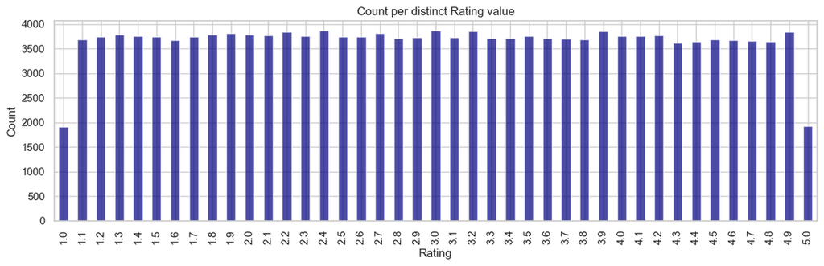

```python
# 11) Rating value granularity — exact rating frequencies
vc = df['Rating'].value_counts().sort_index()
plt.figure(figsize=(12, 4))
vc.plot(kind='bar', color='navy', alpha=0.7)
plt.title('Count per distinct Rating value')
plt.xlabel('Rating')
plt.ylabel('Count')
plt.tight_layout()
plt.show()

# Target Variable is Uniformly Distributed
```

DATA EXPLORATION RESULTS:

- Data is very well **distributed and balanced** - Almost too well (Synthetic Data).
- Data has **no missing** columns or rows.
- Data has **no outliers or weird values** to fix.